# Introduction to Computer Vision: Plant Seedlings Classification

## Problem Statement

### Context

In recent times, the field of agriculture has been in urgent need of modernizing, since the amount of manual work people need to put in to check if plants are growing correctly is still highly extensive. Despite several advances in agricultural technology, people working in the agricultural industry still need to have the ability to sort and recognize different plants and weeds, which takes a lot of time and effort in the long term. The potential is ripe for this trillion-dollar industry to be greatly impacted by technological innovations that cut down on the requirement for manual labor, and this is where Artificial Intelligence can actually benefit the workers in this field, as **the time and energy required to identify plant seedlings will be greatly shortened by the use of AI and Deep Learning.** The ability to do so far more efficiently and even more effectively than experienced manual labor, could lead to better crop yields, the freeing up of human inolvement for higher-order agricultural decision making, and in the long term will result in more sustainable environmental practices in agriculture as well.

### Objective

The aim of this project is to Build a Convolutional Neural Netowrk to classify plant seedlings into their respective categories.

### Data Dictionary

[output not shown]

The Aarhus University Signal Processing group, in collaboration with the University of Southern Denmark, has recently released a dataset containing **images of unique plants belonging to 12 different species.**

- The dataset can be download from Olympus.
- The data file names are:
  - images.npy
  - Labels.csv
- Due to the large volume of data, the images were converted to the images.npy file and the labels are also put into Labels.csv, so that you can work on the data/project seamlessly without having to worry about the high data volume.
- The goal of the project is to create a classifier capable of determining a plant's species from an image.

**List of Species**

- Black-grass
- Charlock
- Cleavers
- Common Chickweed
- Common Wheat
- Fat Hen
- Loose Silky-bent
- Maize
- Scentless Mayweed
- Shepherds Purse
- Small-flowered Cranesbill
- Sugar beet

### **Note: Please use GPU runtime on Google Colab to execute the code faster.**

## Importing necessary libraries

```python
# Installing the libraries with the specified version.
# uncomment and run the following line if Google Colab is being used
!pip install tensorflow==2.15.0 scikit-learn==1.2.2 seaborn==0.13.1 matplotlib==3.7.1 numpy==1.25.2 pandas==1.5.3 opencv-python==4.8.0.76 -q --user
```

**Note**: *After running the above cell, kindly restart the notebook kernel and run all cells sequentially from the start again.*

```python
import os
import numpy as np
import pandas as pd
import matplotlib.pyplot as plt
import math
import cv2
import seaborn as sns


# Tensorflow modules
import tensorflow as tf
from tensorflow.keras.preprocessing.image import ImageDataGenerator
from tensorflow.keras.models import Sequential
from tensorflow.keras.layers import Dense,Dropout,Flatten,Conv2D,MaxPooling2D,BatchNormalization
from tensorflow.keras.optimizers import Adam,SGD
from sklearn import preprocessing
from sklearn.model_selection import train_test_split
from sklearn.metrics import confusion_matrix
from sklearn.preprocessing import LabelBinarizer
# Display images using OpenCV
from google.colab.patches import cv2_imshow
from sklearn.model_selection import train_test_split
from tensorflow.keras import backend
from keras.callbacks import ReduceLROnPlateau
import random
# Ignore warnings
import warnings
warnings.filterwarnings('ignore')
```

## Loading the dataset

```python
# Uncomment and run the below code if you are using google colab
from google.colab import drive
drive.mount('/content/drive')
```

```python
# Loading plant images and Labels from the respective files
images= np.load("/content/drive/MyDrive/images_plant-2.npy")
labels= pd.read_csv("/content/drive/MyDrive/Labels.csv")
```

## Data Overview

### Understand the shape of the dataset

```python
# Shape of the images
print(images.shape)
```

```
(4750, 128, 128, 3)
```

**Observations**

1. The dataset contains 4750 RGB images
2. Images shapes are 128x128 pixels, each containing 3 channels.

```python
print(labels.shape)
```

```
(4750, 1)
```

**Observations**

1. There are 4,750 rows (one for each image).
2. There is 1 column (the plant species label).

```python
#  first few labels check
print(labels.head())
```

```
                       Label
0  Small-flowered Cranesbill
1  Small-flowered Cranesbill
2  Small-flowered Cranesbill
3  Small-flowered Cranesbill
4  Small-flowered Cranesbill
```

```python
# Unique classes and their counts
print("\nUnique Species\n", labels['Label'].unique())
print("\nClass Counts\n", labels['Label'].value_counts())
```

```
Unique Species
 ['Small-flowered Cranesbill' 'Fat Hen' 'Shepherds Purse' 'Common wheat'
 'Common Chickweed' 'Charlock' 'Cleavers' 'Scentless Mayweed' 'Sugar beet'
 'Maize' 'Black-grass' 'Loose Silky-bent']

Class Counts
 Label
Loose Silky-bent             654
Common Chickweed             611
Scentless Mayweed            516
Small-flowered Cranesbill    496
Fat Hen                      475
Charlock                     390
Sugar beet                   385
Cleavers                     287
Black-grass                  263
Shepherds Purse              231
Common wheat                 221
Maize                        221
Name: count, dtype: int64
```

```python
#Check for Missing or Duplicated Data
print("Missing values in labels:\n", labels.isnull().sum())
print("Number of duplicate labels:", labels.duplicated().sum())
```

```
Missing values in labels:
 Label    0
dtype: int64
Number of duplicate labels: 4738
```

**Observation**

1. There are no missing values in the labels dataset.
2. There are 4,738 duplicate rows out of 4,750.
3. The duplicates indicates that many images share the same species label.

## Exploratory Data Analysis

- EDA is an important part of any project involving data.
- It is important to investigate and understand the data better before building a model with it.
- A few questions have been mentioned below which will help you understand the data better.
- A thorough analysis of the data, in addition to the questions mentioned below, should be done.
1. How are these different category plant images different from each other?
2. Is the dataset provided an imbalance? (Check with using bar plots)

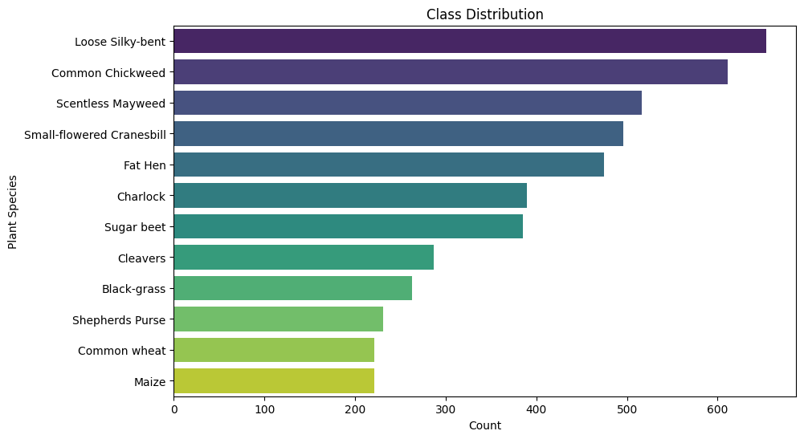

```python
# Class distribution
plt.figure(figsize=(10, 6))
sns.countplot(y=labels['Label'], order=labels['Label'].value_counts().index, palette='viridis')
plt.title('Class Distribution')
plt.xlabel('Count')
plt.ylabel('Plant Species')
plt.show()
```

**Observation**

1. The dataset contains 12 plant species.
2. The number of images per class varies significantly, indicating a class imbalance.
3. Top 3 Classes are - Loose Silky-bent: 654 images, Common Chickweed: 611 images, Scentless Mayweed: 516 images

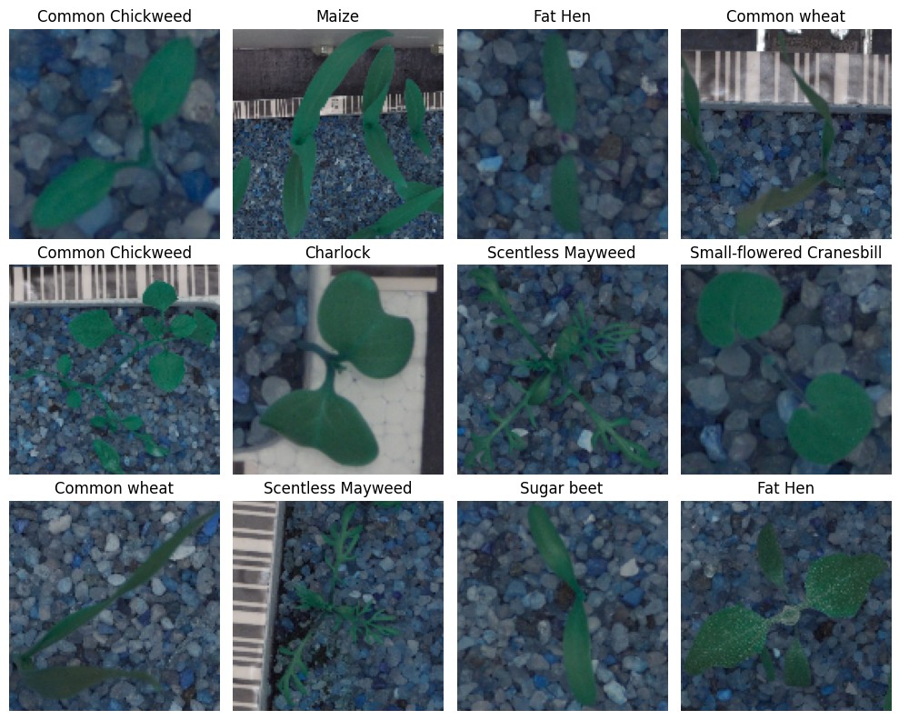

```python
# Random Image samples
def plot_images(images, labels):
    num_classes = len(np.unique(labels))
    categories = np.unique(labels)
    keys = dict(enumerate(categories))  # map index to label
    rows, cols = 3, 4
    fig = plt.figure(figsize=(10, 8))
    for i in range(rows * cols):
        random_index = np.random.randint(0, len(labels))
        ax = fig.add_subplot(rows, cols, i + 1)
        ax.imshow(images[random_index])
        ax.set_title(labels.iloc[random_index, 0])
        ax.axis('off')
    plt.tight_layout()
    plt.show()

plot_images(images, labels)
```

**Observation**

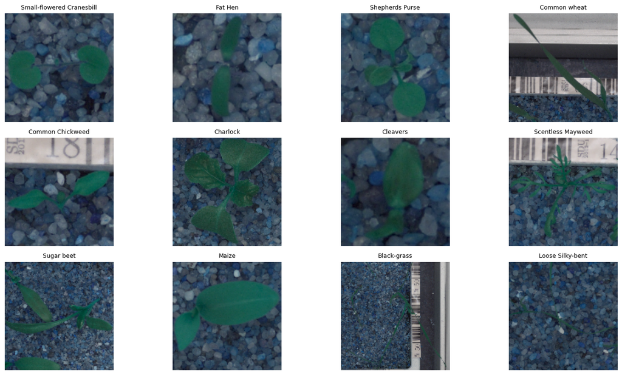

```python
# Class wise image sample
unique_labels = labels['Label'].unique()
plt.figure(figsize=(15, 8))
for i, label in enumerate(unique_labels):
    idx = labels[labels['Label'] == label].index[0]
    plt.subplot(3, 4, i + 1)
    plt.imshow(images[idx])
    plt.title(label, fontsize=9)
    plt.axis('off')
plt.tight_layout()
plt.show()
```

## Data Pre-Processing

### Convert the BGR images to RGB images.

```python
for i in range(len(images)):
    images[i] = cv2.cvtColor(images[i], cv2.COLOR_BGR2RGB)
```

### Resize the images

As the size of the images is large, it may be computationally expensive to train on these larger images; therefore, it is preferable to reduce the image size from 128 to 64.

```python
images_decreased = []
height, width = 64, 64
dimensions = (width, height)
for i in range(len(images)):
    images_decreased.append(cv2.resize(images[i], dimensions, interpolation=cv2.INTER_LINEAR))

images_decreased = np.array(images_decreased)
```

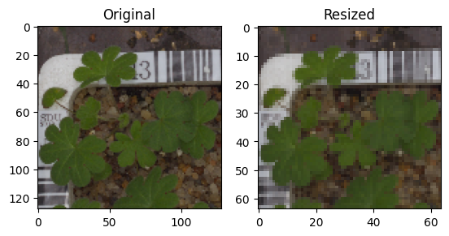

```python
# Display resized image
plt.subplot(1, 2, 1)
plt.title("Original")
plt.imshow(images[3])
plt.subplot(1, 2, 2)
plt.title("Resized")
plt.imshow(images_decreased[3])
plt.show()
```

### Data Preparation for Modeling

- Before you proceed to build a model, you need to split the data into train, test, and validation to be able to evaluate the model that you build on the train data
- You'll have to encode categorical features and scale the pixel values.
- You will build a model using the train data and then check its performance

**Split the dataset**

```python
X_temp, X_test, y_temp, y_test = train_test_split(
    np.array(images_decreased), labels['Label'], test_size=0.1, random_state=42, stratify=labels)

X_train, X_val, y_train, y_val = train_test_split(
    X_temp, y_temp, test_size=0.1, random_state=42, stratify=y_temp)
```

```python
print(X_train.shape, y_train.shape)
print(X_val.shape, y_val.shape)
print(X_test.shape, y_test.shape)
```

```
(3847, 64, 64, 3) (3847,)
(428, 64, 64, 3) (428,)
(475, 64, 64, 3) (475,)
```

### Encode the target labels

```python
enc = LabelBinarizer()
y_train_encoded = enc.fit_transform(y_train)
y_val_encoded = enc.transform(y_val)
y_test_encoded = enc.transform(y_test)
```

```python
print(y_train_encoded.shape, y_val_encoded.shape, y_test_encoded.shape)
```

```
(3847, 12) (428, 12) (475, 12)
```

### Data Normalization

```python
# Normalize test, train and validation data
X_train_normalized = X_train.astype('float32') / 255.0
X_val_normalized = X_val.astype('float32') / 255.0
X_test_normalized = X_test.astype('float32') / 255.0
```

## Model Building

```python
# Build CNN Model

tf.keras.backend.clear_session()
np.random.seed(42)
random.seed(42)
tf.random.set_seed(42)

model1 = Sequential()

model1.add(Conv2D(128, (3, 3), activation='relu', padding="same", input_shape=(64, 64, 3)))
model1.add(MaxPooling2D((2, 2), padding='same'))

model1.add(Conv2D(64, (3, 3), activation='relu', padding="same"))
model1.add(MaxPooling2D((2, 2), padding='same'))

model1.add(Conv2D(32, (3, 3), activation='relu', padding="same"))
model1.add(MaxPooling2D((2, 2), padding='same'))

model1.add(Flatten())
model1.add(Dense(16, activation='relu'))
model1.add(Dropout(0.3))
model1.add(Dense(12, activation='softmax'))

opt = Adam()
model1.compile(optimizer=opt, loss='categorical_crossentropy', metrics=['accuracy'])
model1.summary()
```

```
Model: "sequential"
```

```
┏━━━━━━━━━━━━━━━━━━━━━━━━━━━━━━━━━┳━━━━━━━━━━━━━━━━━━━━━━━━┳━━━━━━━━━━━━━━━┓
┃ Layer (type)                    ┃ Output Shape           ┃       Param # ┃
┡━━━━━━━━━━━━━━━━━━━━━━━━━━━━━━━━━╇━━━━━━━━━━━━━━━━━━━━━━━━╇━━━━━━━━━━━━━━━┩
│ conv2d (Conv2D)                 │ (None, 64, 64, 128)    │         3,584 │
├─────────────────────────────────┼────────────────────────┼───────────────┤
│ max_pooling2d (MaxPooling2D)    │ (None, 32, 32, 128)    │             0 │
├─────────────────────────────────┼────────────────────────┼───────────────┤
│ conv2d_1 (Conv2D)               │ (None, 32, 32, 64)     │        73,792 │
├─────────────────────────────────┼────────────────────────┼───────────────┤
│ max_pooling2d_1 (MaxPooling2D)  │ (None, 16, 16, 64)     │             0 │
├─────────────────────────────────┼────────────────────────┼───────────────┤
│ conv2d_2 (Conv2D)               │ (None, 16, 16, 32)     │        18,464 │
├─────────────────────────────────┼────────────────────────┼───────────────┤
│ max_pooling2d_2 (MaxPooling2D)  │ (None, 8, 8, 32)       │             0 │
├─────────────────────────────────┼────────────────────────┼───────────────┤
│ flatten (Flatten)               │ (None, 2048)           │             0 │
├─────────────────────────────────┼────────────────────────┼───────────────┤
│ dense (Dense)                   │ (None, 16)             │        32,784 │
├─────────────────────────────────┼────────────────────────┼───────────────┤
│ dropout (Dropout)               │ (None, 16)             │             0 │
├─────────────────────────────────┼────────────────────────┼───────────────┤
│ dense_1 (Dense)                 │ (None, 12)             │           204 │
└─────────────────────────────────┴────────────────────────┴───────────────┘
```

```
 Total params: 128,828 (503.23 KB)
```

```
 Trainable params: 128,828 (503.23 KB)
```

```
 Non-trainable params: 0 (0.00 B)
```

**Fitting the model on the train data**

```python
# Train Model
history_1 = model1.fit(
    X_train_normalized, y_train_encoded,
    epochs=30,
    validation_data=(X_val_normalized, y_val_encoded),
    batch_size=32,
    verbose=2
)
```

```
121/121 - 12s - 103ms/step - accuracy: 0.1157 - loss: 2.4640 - val_accuracy: 0.1379 - val_loss: 2.4362
121/121 - 12s - 96ms/step - accuracy: 0.2004 - loss: 2.2573 - val_accuracy: 0.3364 - val_loss: 1.9726
121/121 - 1s - 11ms/step - accuracy: 0.3101 - loss: 1.9874 - val_accuracy: 0.3481 - val_loss: 1.8420
121/121 - 1s - 12ms/step - accuracy: 0.3278 - loss: 1.8773 - val_accuracy: 0.3949 - val_loss: 1.7013
121/121 - 2s - 19ms/step - accuracy: 0.3327 - loss: 1.8298 - val_accuracy: 0.3808 - val_loss: 1.6798
121/121 - 2s - 20ms/step - accuracy: 0.3442 - loss: 1.7842 - val_accuracy: 0.3972 - val_loss: 1.6203
121/121 - 1s - 10ms/step - accuracy: 0.3533 - loss: 1.7267 - val_accuracy: 0.4112 - val_loss: 1.5548
121/121 - 1s - 11ms/step - accuracy: 0.3702 - loss: 1.6952 - val_accuracy: 0.4299 - val_loss: 1.5262
121/121 - 2s - 20ms/step - accuracy: 0.3824 - loss: 1.6613 - val_accuracy: 0.4556 - val_loss: 1.4877
121/121 - 1s - 10ms/step - accuracy: 0.3967 - loss: 1.6217 - val_accuracy: 0.4930 - val_loss: 1.4064
121/121 - 1s - 11ms/step - accuracy: 0.4047 - loss: 1.5957 - val_accuracy: 0.5164 - val_loss: 1.3835
121/121 - 1s - 12ms/step - accuracy: 0.4034 - loss: 1.5730 - val_accuracy: 0.5023 - val_loss: 1.3957
121/121 - 2s - 19ms/step - accuracy: 0.4136 - loss: 1.5371 - val_accuracy: 0.5327 - val_loss: 1.3257
121/121 - 1s - 10ms/step - accuracy: 0.4242 - loss: 1.5215 - val_accuracy: 0.5607 - val_loss: 1.3488
121/121 - 1s - 10ms/step - accuracy: 0.4263 - loss: 1.5066 - val_accuracy: 0.5678 - val_loss: 1.2880
121/121 - 1s - 10ms/step - accuracy: 0.4354 - loss: 1.4835 - val_accuracy: 0.5491 - val_loss: 1.3116
121/121 - 1s - 11ms/step - accuracy: 0.4536 - loss: 1.4491 - val_accuracy: 0.5397 - val_loss: 1.3503
121/121 - 1s - 10ms/step - accuracy: 0.4463 - loss: 1.4499 - val_accuracy: 0.5467 - val_loss: 1.3211
121/121 - 1s - 10ms/step - accuracy: 0.4497 - loss: 1.4472 - val_accuracy: 0.4556 - val_loss: 1.4266
121/121 - 1s - 10ms/step - accuracy: 0.4648 - loss: 1.4108 - val_accuracy: 0.5981 - val_loss: 1.2231
121/121 - 1s - 12ms/step - accuracy: 0.4666 - loss: 1.3992 - val_accuracy: 0.5234 - val_loss: 1.3338
121/121 - 1s - 12ms/step - accuracy: 0.4619 - loss: 1.4192 - val_accuracy: 0.5350 - val_loss: 1.3424
121/121 - 1s - 11ms/step - accuracy: 0.4630 - loss: 1.3985 - val_accuracy: 0.5491 - val_loss: 1.3128
121/121 - 1s - 10ms/step - accuracy: 0.4731 - loss: 1.3639 - val_accuracy: 0.5374 - val_loss: 1.2973
121/121 - 1s - 11ms/step - accuracy: 0.4819 - loss: 1.3563 - val_accuracy: 0.5748 - val_loss: 1.2449
121/121 - 1s - 10ms/step - accuracy: 0.4890 - loss: 1.3458 - val_accuracy: 0.5818 - val_loss: 1.2257
121/121 - 1s - 10ms/step - accuracy: 0.4905 - loss: 1.3315 - val_accuracy: 0.5864 - val_loss: 1.2196
121/121 - 1s - 11ms/step - accuracy: 0.4861 - loss: 1.3423 - val_accuracy: 0.5794 - val_loss: 1.2513
121/121 - 1s - 10ms/step - accuracy: 0.5027 - loss: 1.2973 - val_accuracy: 0.5654 - val_loss: 1.2554
121/121 - 1s - 10ms/step - accuracy: 0.5066 - loss: 1.2821 - val_accuracy: 0.5794 - val_loss: 1.2153
```

**Model Evaluation**

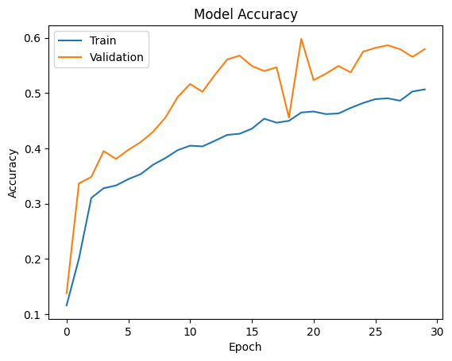

```python
# Plot Training Accuracy
plt.plot(history_1.history['accuracy'])
plt.plot(history_1.history['val_accuracy'])
plt.title('Model Accuracy')
plt.ylabel('Accuracy')
plt.xlabel('Epoch')
plt.legend(['Train', 'Validation'], loc='upper left')
plt.show()
```

**Observation**

1. The model is learning, but it’s: Underfitting slightly (training accuracy is too low).
2. The training accuracy starts low (~0.1) and increases steadily to around 50% by the end of 30 epochs, indicating the model is learning the patterns in the training data.
3. The validation accuracy shows a rapid rise in the initial epochs, reaching ~60% around epoch 20, but exhibits some fluctuations (spikes and drops) between epochs 15-20. This suggests the model is encountering some instability while generalizing to unseen data.

**Evaluate the model on test data**

```python
# Evaluate on Test Data
accuracy = model1.evaluate(X_test_normalized, y_test_encoded, verbose=2)
print(f"Test Accuracy: {accuracy[1]*100:.2f}%")
```

```
15/15 - 1s - 56ms/step - accuracy: 0.5600 - loss: 1.2710
Test Accuracy: 56.00%
```

**Observation**

1. The model achieved a test accuracy of 56% with a loss of 1.2710 on the unseen test dataset.
2. This indicates that the model has learned to classify plant species better than random guessing (baseline: ~8.3% for 12 classes), but there’s still significant room for improvement.
3. The relatively high loss suggests some misclassifications and possible difficulty in distinguishing visually similar species.

**Plotting the Confusion Matrix**

```
15/15 ━━━━━━━━━━━━━━━━━━━━ 1s 59ms/step
```

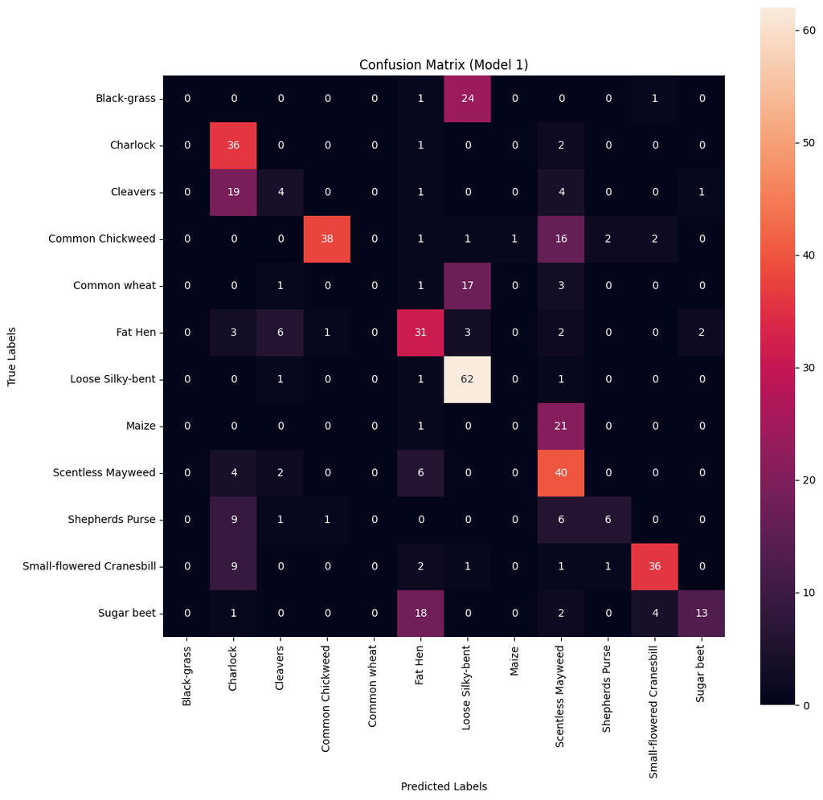

```python
# Confusion matrix for Model 1
y_pred1 = model1.predict(X_test_normalized)
y_pred_arg1 = np.argmax(y_pred1, axis=1)
y_test_arg1 = np.argmax(y_test_encoded, axis=1)
confusion_matrix1 = tf.math.confusion_matrix(y_test_arg1, y_pred_arg1)

plt.figure(figsize=(12, 12))
sns.heatmap(confusion_matrix1.numpy(), annot=True, fmt='d', square=True, xticklabels=enc.classes_, yticklabels=enc.classes_)
plt.xlabel('Predicted Labels')
plt.ylabel('True Labels')
plt.title('Confusion Matrix (Model 1)')
plt.show()
```

**Observation**

**Plotting Classification Report**

```python
from sklearn import metrics
cr = metrics.classification_report(y_test_arg1, y_pred_arg1, target_names=enc.classes_)
print(cr)
```

```
                           precision    recall  f1-score   support

              Black-grass       0.00      0.00      0.00        26
                 Charlock       0.44      0.92      0.60        39
                 Cleavers       0.27      0.14      0.18        29
         Common Chickweed       0.95      0.62      0.75        61
             Common wheat       0.00      0.00      0.00        22
                  Fat Hen       0.48      0.65      0.55        48
         Loose Silky-bent       0.57      0.95      0.72        65
                    Maize       0.00      0.00      0.00        22
        Scentless Mayweed       0.41      0.77      0.53        52
          Shepherds Purse       0.67      0.26      0.38        23
Small-flowered Cranesbill       0.84      0.72      0.77        50
               Sugar beet       0.81      0.34      0.48        38

                 accuracy                           0.56       475
                macro avg       0.45      0.45      0.41       475
             weighted avg       0.53      0.56      0.51       475
```

**Observation**

1. The model struggles with minority classes and visually similar species, leading to imbalanced precision and recall across classes.
2. Weighted average F1-score (0.51) highlights the need for better generalization.

## Model Performance Improvement

**Reducing the Learning Rate:**

**Hint**: Use **ReduceLRonPlateau()** function that will be used to decrease the learning rate by some factor, if the loss is not decreasing for some time. This may start decreasing the loss at a smaller learning rate. There is a possibility that the loss may still not decrease. This may lead to executing the learning rate reduction again in an attempt to achieve a lower loss.

```python
# Reduce learning rate
learning_rate_reduction = ReduceLROnPlateau(monitor='val_accuracy',
                                            patience=3,
                                            verbose=1,
                                            factor=0.5,
                                            min_lr=0.00001)
```

### **Data Augmentation**

Remember, **data augmentation should not be used in the validation/test data set**.

```python
# Clearing backend
from tensorflow.keras import backend
backend.clear_session()

# Data augmentation with rotation
from tensorflow.keras.preprocessing.image import ImageDataGenerator
train_datagen = ImageDataGenerator(
    rotation_range=20,
    fill_mode='nearest'
)
```

```python
model2 = Sequential()

# First convolutional layer with 64 filters and 3x3 kernel
model2.add(Conv2D(64, (3, 3), activation='relu', padding="same", input_shape=(64, 64, 3)))

# Max pooling layer
model2.add(MaxPooling2D((2, 2), padding='same'))

# Second convolutional block
model2.add(Conv2D(32, (3, 3), activation='relu', padding="same"))
model2.add(MaxPooling2D((2, 2), padding='same'))
model2.add(BatchNormalization())

# Flatten the output
model2.add(Flatten())

# Fully connected dense layer
model2.add(Dense(16, activation='relu'))

# Dropout layer with dropout_rate=0.3
model2.add(Dropout(0.3))

# Output layer with 12 neurons (for 12 classes) and softmax activation
model2.add(Dense(12, activation='softmax'))

# Initialize Adam optimizer
opt = Adam()

# Compile the model
model2.compile(optimizer=opt, loss='categorical_crossentropy', metrics=['accuracy'])

# Generate summary of the model
model2.summary()
```

```
Model: "sequential"
```

```
┏━━━━━━━━━━━━━━━━━━━━━━━━━━━━━━━━━┳━━━━━━━━━━━━━━━━━━━━━━━━┳━━━━━━━━━━━━━━━┓
┃ Layer (type)                    ┃ Output Shape           ┃       Param # ┃
┡━━━━━━━━━━━━━━━━━━━━━━━━━━━━━━━━━╇━━━━━━━━━━━━━━━━━━━━━━━━╇━━━━━━━━━━━━━━━┩
│ conv2d (Conv2D)                 │ (None, 64, 64, 64)     │         1,792 │
├─────────────────────────────────┼────────────────────────┼───────────────┤
│ max_pooling2d (MaxPooling2D)    │ (None, 32, 32, 64)     │             0 │
├─────────────────────────────────┼────────────────────────┼───────────────┤
│ conv2d_1 (Conv2D)               │ (None, 32, 32, 32)     │        18,464 │
├─────────────────────────────────┼────────────────────────┼───────────────┤
│ max_pooling2d_1 (MaxPooling2D)  │ (None, 16, 16, 32)     │             0 │
├─────────────────────────────────┼────────────────────────┼───────────────┤
│ batch_normalization             │ (None, 16, 16, 32)     │           128 │
│ (BatchNormalization)            │                        │               │
├─────────────────────────────────┼────────────────────────┼───────────────┤
│ flatten (Flatten)               │ (None, 8192)           │             0 │
├─────────────────────────────────┼────────────────────────┼───────────────┤
│ dense (Dense)                   │ (None, 16)             │       131,088 │
├─────────────────────────────────┼────────────────────────┼───────────────┤
│ dropout (Dropout)               │ (None, 16)             │             0 │
├─────────────────────────────────┼────────────────────────┼───────────────┤
│ dense_1 (Dense)                 │ (None, 12)             │           204 │
└─────────────────────────────────┴────────────────────────┴───────────────┘
```

```
 Total params: 151,676 (592.48 KB)
```

```
 Trainable params: 151,612 (592.23 KB)
```

```
 Non-trainable params: 64 (256.00 B)
```

**Fitting the model on the train data**

```python
# Fit the model
epochs = 30
batch_size = 64

history = model2.fit(
    train_datagen.flow(X_train_normalized, y_train_encoded,
                       batch_size=batch_size,
                       shuffle=False),
    epochs=epochs,
    steps_per_epoch=X_train_normalized.shape[0] // batch_size,
    validation_data=(X_val_normalized, y_val_encoded),
    verbose=1,
    callbacks=[learning_rate_reduction]
)
```

```
60/60 ━━━━━━━━━━━━━━━━━━━━ 13s 151ms/step - accuracy: 0.1407 - loss: 2.3973 - val_accuracy: 0.1986 - val_loss: 2.4175 - learning_rate: 0.0010
60/60 ━━━━━━━━━━━━━━━━━━━━ 0s 1ms/step - accuracy: 0.2812 - loss: 1.9112 - val_accuracy: 0.2173 - val_loss: 2.4189 - learning_rate: 0.0010
60/60 ━━━━━━━━━━━━━━━━━━━━ 4s 71ms/step - accuracy: 0.3455 - loss: 1.9071 - val_accuracy: 0.2009 - val_loss: 2.2912 - learning_rate: 0.0010
60/60 ━━━━━━━━━━━━━━━━━━━━ 0s 2ms/step - accuracy: 0.3906 - loss: 1.7943 - val_accuracy: 0.2196 - val_loss: 2.2905 - learning_rate: 0.0010
60/60 ━━━━━━━━━━━━━━━━━━━━ 6s 94ms/step - accuracy: 0.4304 - loss: 1.6268 - val_accuracy: 0.2547 - val_loss: 2.2135 - learning_rate: 0.0010
60/60 ━━━━━━━━━━━━━━━━━━━━ 0s 2ms/step - accuracy: 0.4531 - loss: 1.3717 - val_accuracy: 0.2477 - val_loss: 2.2166 - learning_rate: 0.0010
60/60 ━━━━━━━━━━━━━━━━━━━━ 9s 72ms/step - accuracy: 0.4927 - loss: 1.4442 - val_accuracy: 0.3388 - val_loss: 2.0334 - learning_rate: 0.0010
60/60 ━━━━━━━━━━━━━━━━━━━━ 0s 1ms/step - accuracy: 0.4375 - loss: 1.5289 - val_accuracy: 0.3154 - val_loss: 2.0334 - learning_rate: 0.0010
60/60 ━━━━━━━━━━━━━━━━━━━━ 6s 92ms/step - accuracy: 0.5176 - loss: 1.3615 - val_accuracy: 0.5000 - val_loss: 1.8067 - learning_rate: 0.0010
60/60 ━━━━━━━━━━━━━━━━━━━━ 0s 1ms/step - accuracy: 0.5469 - loss: 1.3865 - val_accuracy: 0.5187 - val_loss: 1.8087 - learning_rate: 0.0010
60/60 ━━━━━━━━━━━━━━━━━━━━ 9s 78ms/step - accuracy: 0.5473 - loss: 1.2633 - val_accuracy: 0.5023 - val_loss: 1.6405 - learning_rate: 0.0010
60/60 ━━━━━━━━━━━━━━━━━━━━ 0s 2ms/step - accuracy: 0.5938 - loss: 1.0195 - val_accuracy: 0.5047 - val_loss: 1.6355 - learning_rate: 0.0010
60/60 ━━━━━━━━━━━━━━━━━━━━ 0s 82ms/step - accuracy: 0.5525 - loss: 1.2800
Epoch 13: ReduceLROnPlateau reducing learning rate to 0.0005000000237487257.
60/60 ━━━━━━━━━━━━━━━━━━━━ 5s 85ms/step - accuracy: 0.5523 - loss: 1.2800 - val_accuracy: 0.4089 - val_loss: 1.6405 - learning_rate: 0.0010
60/60 ━━━━━━━━━━━━━━━━━━━━ 0s 1ms/step - accuracy: 0.5625 - loss: 1.1977 - val_accuracy: 0.3855 - val_loss: 1.6803 - learning_rate: 5.0000e-04
60/60 ━━━━━━━━━━━━━━━━━━━━ 4s 70ms/step - accuracy: 0.5678 - loss: 1.1999 - val_accuracy: 0.5701 - val_loss: 1.2882 - learning_rate: 5.0000e-04
60/60 ━━━━━━━━━━━━━━━━━━━━ 0s 1ms/step - accuracy: 0.6406 - loss: 1.0870 - val_accuracy: 0.5561 - val_loss: 1.2806 - learning_rate: 5.0000e-04
60/60 ━━━━━━━━━━━━━━━━━━━━ 5s 92ms/step - accuracy: 0.5758 - loss: 1.1687 - val_accuracy: 0.6215 - val_loss: 1.2469 - learning_rate: 5.0000e-04
60/60 ━━━━━━━━━━━━━━━━━━━━ 0s 2ms/step - accuracy: 0.6406 - loss: 1.0309 - val_accuracy: 0.6215 - val_loss: 1.2051 - learning_rate: 5.0000e-04
60/60 ━━━━━━━━━━━━━━━━━━━━ 4s 70ms/step - accuracy: 0.5769 - loss: 1.1224 - val_accuracy: 0.4603 - val_loss: 1.5727 - learning_rate: 5.0000e-04
 1/60 ━━━━━━━━━━━━━━━━━━━━ 0s 13ms/step - accuracy: 0.4062 - loss: 1.4792
Epoch 20: ReduceLROnPlateau reducing learning rate to 0.0002500000118743628.
60/60 ━━━━━━━━━━━━━━━━━━━━ 0s 1ms/step - accuracy: 0.4062 - loss: 1.4792 - val_accuracy: 0.4743 - val_loss: 1.5333 - learning_rate: 5.0000e-04
60/60 ━━━━━━━━━━━━━━━━━━━━ 5s 71ms/step - accuracy: 0.6162 - loss: 1.0739 - val_accuracy: 0.6706 - val_loss: 1.0558 - learning_rate: 2.5000e-04
60/60 ━━━━━━━━━━━━━━━━━━━━ 0s 1ms/step - accuracy: 0.5938 - loss: 1.0864 - val_accuracy: 0.6706 - val_loss: 1.0523 - learning_rate: 2.5000e-04
60/60 ━━━━━━━━━━━━━━━━━━━━ 6s 94ms/step - accuracy: 0.6141 - loss: 1.0864 - val_accuracy: 0.6215 - val_loss: 1.1725 - learning_rate: 2.5000e-04
 1/60 ━━━━━━━━━━━━━━━━━━━━ 1s 18ms/step - accuracy: 0.6406 - loss: 1.0310
Epoch 24: ReduceLROnPlateau reducing learning rate to 0.0001250000059371814.
60/60 ━━━━━━━━━━━━━━━━━━━━ 0s 2ms/step - accuracy: 0.6406 - loss: 1.0310 - val_accuracy: 0.6262 - val_loss: 1.1552 - learning_rate: 2.5000e-04
60/60 ━━━━━━━━━━━━━━━━━━━━ 4s 73ms/step - accuracy: 0.6192 - loss: 1.0480 - val_accuracy: 0.6379 - val_loss: 1.0925 - learning_rate: 1.2500e-04
60/60 ━━━━━━━━━━━━━━━━━━━━ 0s 1ms/step - accuracy: 0.6250 - loss: 1.1033 - val_accuracy: 0.6449 - val_loss: 1.0880 - learning_rate: 1.2500e-04
60/60 ━━━━━━━━━━━━━━━━━━━━ 7s 105ms/step - accuracy: 0.6141 - loss: 1.0829 - val_accuracy: 0.6893 - val_loss: 0.9870 - learning_rate: 1.2500e-04
60/60 ━━━━━━━━━━━━━━━━━━━━ 0s 3ms/step - accuracy: 0.6562 - loss: 0.9572 - val_accuracy: 0.6893 - val_loss: 0.9890 - learning_rate: 1.2500e-04
60/60 ━━━━━━━━━━━━━━━━━━━━ 4s 73ms/step - accuracy: 0.6277 - loss: 1.0491 - val_accuracy: 0.6472 - val_loss: 1.1057 - learning_rate: 1.2500e-04
 1/60 ━━━━━━━━━━━━━━━━━━━━ 0s 12ms/step - accuracy: 0.6562 - loss: 1.0130
Epoch 30: ReduceLROnPlateau reducing learning rate to 6.25000029685907e-05.
60/60 ━━━━━━━━━━━━━━━━━━━━ 0s 1ms/step - accuracy: 0.6562 - loss: 1.0130 - val_accuracy: 0.6308 - val_loss: 1.1557 - learning_rate: 1.2500e-04
```

**Model Evaluation**

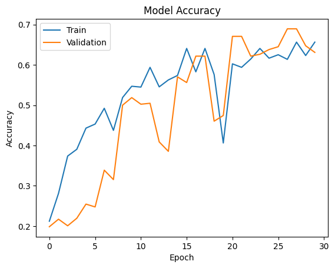

```python
# Plot accuracy
import matplotlib.pyplot as plt
plt.plot(history.history['accuracy'])
plt.plot(history.history['val_accuracy'])
plt.title('Model Accuracy')
plt.ylabel('Accuracy')
plt.xlabel('Epoch')
plt.legend(['Train', 'Validation'], loc='upper left')
plt.show()
```

**Observation**

**Evaluate the model on test data**

```python
# Evaluate the model on test data
accuracy = model2.evaluate(X_test_normalized, y_test_encoded, verbose=2)
print(f"Test Accuracy: {accuracy[1]*100:.2f}%")
```

```
15/15 - 1s - 80ms/step - accuracy: 0.5979 - loss: 1.1827
Test Accuracy: 59.79%
```

**Observation**

**Plotting the Confusion Matrix**

```
15/15 ━━━━━━━━━━━━━━━━━━━━ 1s 53ms/step
```

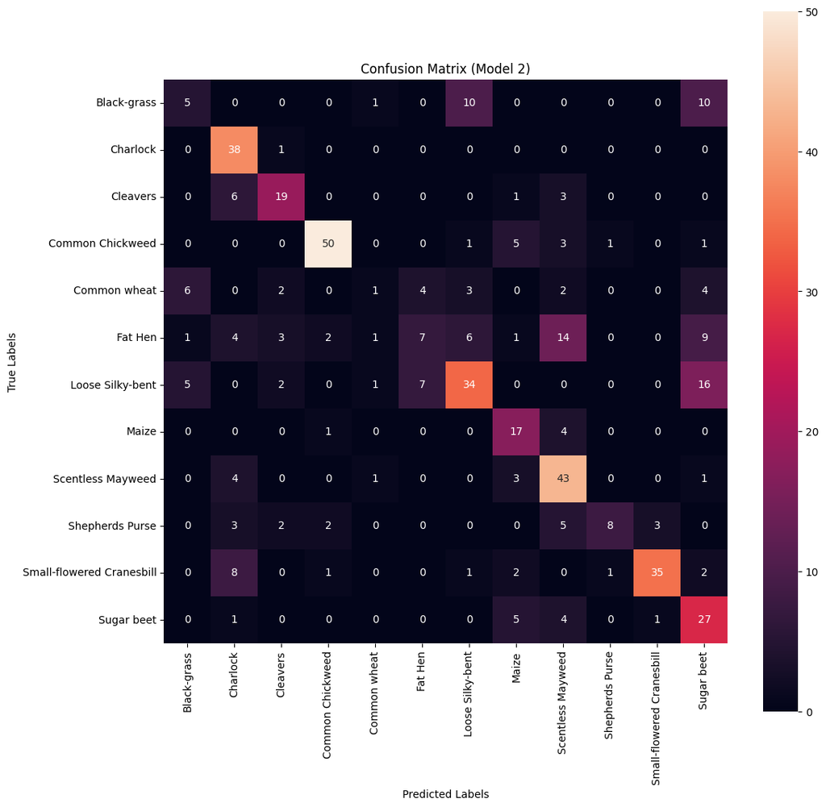

```python
# Confusion matrix for Model 2
y_pred2 = model2.predict(X_test_normalized)
y_pred_arg2 = np.argmax(y_pred2, axis=1)
y_test_arg2 = np.argmax(y_test_encoded, axis=1)
confusion_matrix2 = tf.math.confusion_matrix(y_test_arg2, y_pred_arg2)

plt.figure(figsize=(12, 12))
sns.heatmap(confusion_matrix2.numpy(), annot=True, fmt='d', square=True, xticklabels=enc.classes_, yticklabels=enc.classes_)
plt.xlabel('Predicted Labels')
plt.ylabel('True Labels')
plt.title('Confusion Matrix (Model 2)')
plt.show()
```

**Observation**

1. Model 2 shows better balance across classes and fewer extreme misclassifications compared to Model 1.
2. Recall for minority classes improved, but precision for overlapping species needs further optimization.

```python
# Classification report
print(metrics.classification_report(y_test_arg2, y_pred_arg2, target_names=enc.classes_))
```

```
                           precision    recall  f1-score   support

              Black-grass       0.29      0.19      0.23        26
                 Charlock       0.59      0.97      0.74        39
                 Cleavers       0.66      0.66      0.66        29
         Common Chickweed       0.89      0.82      0.85        61
             Common wheat       0.20      0.05      0.07        22
                  Fat Hen       0.39      0.15      0.21        48
         Loose Silky-bent       0.62      0.52      0.57        65
                    Maize       0.50      0.77      0.61        22
        Scentless Mayweed       0.55      0.83      0.66        52
          Shepherds Purse       0.80      0.35      0.48        23
Small-flowered Cranesbill       0.90      0.70      0.79        50
               Sugar beet       0.39      0.71      0.50        38

                 accuracy                           0.60       475
                macro avg       0.56      0.56      0.53       475
             weighted avg       0.60      0.60      0.57       475
```

**Observation**

1. Model 2 exhibits better balance across classes and a higher weighted F1-score (0.57), demonstrating enhanced generalization, but still struggles with some visually similar and underrepresented species.

**Transfer Learning with VGG 16**

```python
#clearing backend
backend.clear_session()
#setting the seed for random number generators
import random
np.random.seed(42)
random.seed(42)
tf.random.set_seed(42)
```

```python
#importing the convolutional layers of the VGG 16 model
from keras.applications.vgg16 import VGG16
vgg_model = VGG16(weights='imagenet', include_top = False, input_shape = (64,64,3))
vgg_model.summary()
```

```
Downloading data from https://storage.googleapis.com/tensorflow/keras-applications/vgg16/vgg16_weights_tf_dim_ordering_tf_kernels_notop.h5
58889256/58889256 ━━━━━━━━━━━━━━━━━━━━ 0s 0us/step
```

```
Model: "vgg16"
```

```
┏━━━━━━━━━━━━━━━━━━━━━━━━━━━━━━━━━┳━━━━━━━━━━━━━━━━━━━━━━━━┳━━━━━━━━━━━━━━━┓
┃ Layer (type)                    ┃ Output Shape           ┃       Param # ┃
┡━━━━━━━━━━━━━━━━━━━━━━━━━━━━━━━━━╇━━━━━━━━━━━━━━━━━━━━━━━━╇━━━━━━━━━━━━━━━┩
│ input_layer (InputLayer)        │ (None, 64, 64, 3)      │             0 │
├─────────────────────────────────┼────────────────────────┼───────────────┤
│ block1_conv1 (Conv2D)           │ (None, 64, 64, 64)     │         1,792 │
├─────────────────────────────────┼────────────────────────┼───────────────┤
│ block1_conv2 (Conv2D)           │ (None, 64, 64, 64)     │        36,928 │
├─────────────────────────────────┼────────────────────────┼───────────────┤
│ block1_pool (MaxPooling2D)      │ (None, 32, 32, 64)     │             0 │
├─────────────────────────────────┼────────────────────────┼───────────────┤
│ block2_conv1 (Conv2D)           │ (None, 32, 32, 128)    │        73,856 │
├─────────────────────────────────┼────────────────────────┼───────────────┤
│ block2_conv2 (Conv2D)           │ (None, 32, 32, 128)    │       147,584 │
├─────────────────────────────────┼────────────────────────┼───────────────┤
│ block2_pool (MaxPooling2D)      │ (None, 16, 16, 128)    │             0 │
├─────────────────────────────────┼────────────────────────┼───────────────┤
│ block3_conv1 (Conv2D)           │ (None, 16, 16, 256)    │       295,168 │
├─────────────────────────────────┼────────────────────────┼───────────────┤
│ block3_conv2 (Conv2D)           │ (None, 16, 16, 256)    │       590,080 │
├─────────────────────────────────┼────────────────────────┼───────────────┤
│ block3_conv3 (Conv2D)           │ (None, 16, 16, 256)    │       590,080 │
├─────────────────────────────────┼────────────────────────┼───────────────┤
│ block3_pool (MaxPooling2D)      │ (None, 8, 8, 256)      │             0 │
├─────────────────────────────────┼────────────────────────┼───────────────┤
│ block4_conv1 (Conv2D)           │ (None, 8, 8, 512)      │     1,180,160 │
├─────────────────────────────────┼────────────────────────┼───────────────┤
│ block4_conv2 (Conv2D)           │ (None, 8, 8, 512)      │     2,359,808 │
├─────────────────────────────────┼────────────────────────┼───────────────┤
│ block4_conv3 (Conv2D)           │ (None, 8, 8, 512)      │     2,359,808 │
├─────────────────────────────────┼────────────────────────┼───────────────┤
│ block4_pool (MaxPooling2D)      │ (None, 4, 4, 512)      │             0 │
├─────────────────────────────────┼────────────────────────┼───────────────┤
│ block5_conv1 (Conv2D)           │ (None, 4, 4, 512)      │     2,359,808 │
├─────────────────────────────────┼────────────────────────┼───────────────┤
│ block5_conv2 (Conv2D)           │ (None, 4, 4, 512)      │     2,359,808 │
├─────────────────────────────────┼────────────────────────┼───────────────┤
│ block5_conv3 (Conv2D)           │ (None, 4, 4, 512)      │     2,359,808 │
├─────────────────────────────────┼────────────────────────┼───────────────┤
│ block5_pool (MaxPooling2D)      │ (None, 2, 2, 512)      │             0 │
└─────────────────────────────────┴────────────────────────┴───────────────┘
```

```
 Total params: 14,714,688 (56.13 MB)
```

```
 Trainable params: 14,714,688 (56.13 MB)
```

```
 Non-trainable params: 0 (0.00 B)
```

```python
num_layers = len(vgg_model.layers)
# setting all of layers of the VGG model to non-trainable except the two lowest
for layer in vgg_model.layers[:num_layers-2]:
    layer.trainable = False
```

```python
#confirming non-trainable and trainable layers
for layer in vgg_model.layers:
    print(layer.name, layer.trainable)
```

```
input_layer False
block1_conv1 False
block1_conv2 False
block1_pool False
block2_conv1 False
block2_conv2 False
block2_pool False
block3_conv1 False
block3_conv2 False
block3_conv3 False
block3_pool False
block4_conv1 False
block4_conv2 False
block4_conv3 False
block4_pool False
block5_conv1 False
block5_conv2 False
block5_conv3 True
block5_pool True
```

```python
#creating new sequential model
model3 = Sequential()

#adding the convolutional part of the VGG16 model from above
model3.add(vgg_model)

#flattening the output of the VGG16 model
model3.add(Flatten())

#adding the fully connected dense layers
model3.add(Dense(64, activation='relu'))
model3.add(Dropout(0.25))
model3.add(Dense(32, activation='relu'))
model3.add(Dropout(0.25))
model3.add(Dense(16, activation='relu'))

#adding the output layer with 12 neurons and activation functions as softmax, since this is a multi-class classification problem
model3.add(Dense(12, activation='softmax'))

#using SGD optimizer
opt = SGD(learning_rate=0.01, momentum=0.9)

#compiling model
model3.compile(optimizer=opt, loss='categorical_crossentropy', metrics=['accuracy'])

#generating the summary of the model
model3.summary()
```

```
Model: "sequential_1"
```

```
┏━━━━━━━━━━━━━━━━━━━━━━━━━━━━━━━━━┳━━━━━━━━━━━━━━━━━━━━━━━━┳━━━━━━━━━━━━━━━┓
┃ Layer (type)                    ┃ Output Shape           ┃       Param # ┃
┡━━━━━━━━━━━━━━━━━━━━━━━━━━━━━━━━━╇━━━━━━━━━━━━━━━━━━━━━━━━╇━━━━━━━━━━━━━━━┩
│ vgg16 (Functional)              │ (None, 2, 2, 512)      │    14,714,688 │
├─────────────────────────────────┼────────────────────────┼───────────────┤
│ flatten_1 (Flatten)             │ (None, 2048)           │             0 │
├─────────────────────────────────┼────────────────────────┼───────────────┤
│ dense_4 (Dense)                 │ (None, 64)             │       131,136 │
├─────────────────────────────────┼────────────────────────┼───────────────┤
│ dropout_2 (Dropout)             │ (None, 64)             │             0 │
├─────────────────────────────────┼────────────────────────┼───────────────┤
│ dense_5 (Dense)                 │ (None, 32)             │         2,080 │
├─────────────────────────────────┼────────────────────────┼───────────────┤
│ dropout_3 (Dropout)             │ (None, 32)             │             0 │
├─────────────────────────────────┼────────────────────────┼───────────────┤
│ dense_6 (Dense)                 │ (None, 16)             │           528 │
├─────────────────────────────────┼────────────────────────┼───────────────┤
│ dense_7 (Dense)                 │ (None, 12)             │           204 │
└─────────────────────────────────┴────────────────────────┴───────────────┘
```

```
 Total params: 14,848,636 (56.64 MB)
```

```
 Trainable params: 2,493,756 (9.51 MB)
```

```
 Non-trainable params: 12,354,880 (47.13 MB)
```

**Model training**

```python
#setting number of epochs
epochs = 70
#setting the batch size of the generator
batch_size = 64

history_3 = model3.fit(train_datagen.flow(X_train_normalized,y_train_encoded,
                                       batch_size=batch_size,
                                       seed=42,
                                       shuffle=False),
                    epochs=epochs,
                    steps_per_epoch=X_train_normalized.shape[0] // batch_size,
                    validation_data=(X_test_normalized,y_test_encoded),
                    verbose=1)
```

```
60/60 ━━━━━━━━━━━━━━━━━━━━ 25s 237ms/step - accuracy: 0.1164 - loss: 2.4666 - val_accuracy: 0.3011 - val_loss: 2.1713
60/60 ━━━━━━━━━━━━━━━━━━━━ 1s 11ms/step - accuracy: 0.2188 - loss: 2.2213 - val_accuracy: 0.3116 - val_loss: 2.1591
60/60 ━━━━━━━━━━━━━━━━━━━━ 5s 80ms/step - accuracy: 0.2730 - loss: 2.1225 - val_accuracy: 0.3242 - val_loss: 1.8406
60/60 ━━━━━━━━━━━━━━━━━━━━ 0s 5ms/step - accuracy: 0.3438 - loss: 1.9484 - val_accuracy: 0.3305 - val_loss: 1.8345
60/60 ━━━━━━━━━━━━━━━━━━━━ 11s 91ms/step - accuracy: 0.3268 - loss: 1.8601 - val_accuracy: 0.4000 - val_loss: 1.7262
60/60 ━━━━━━━━━━━━━━━━━━━━ 0s 5ms/step - accuracy: 0.4062 - loss: 1.7593 - val_accuracy: 0.4295 - val_loss: 1.6808
60/60 ━━━━━━━━━━━━━━━━━━━━ 5s 80ms/step - accuracy: 0.3495 - loss: 1.7630 - val_accuracy: 0.3326 - val_loss: 1.6960
60/60 ━━━━━━━━━━━━━━━━━━━━ 0s 6ms/step - accuracy: 0.3281 - loss: 1.9422 - val_accuracy: 0.3642 - val_loss: 1.6514
60/60 ━━━━━━━━━━━━━━━━━━━━ 6s 100ms/step - accuracy: 0.3669 - loss: 1.7673 - val_accuracy: 0.4316 - val_loss: 1.5621
60/60 ━━━━━━━━━━━━━━━━━━━━ 0s 6ms/step - accuracy: 0.4375 - loss: 1.6987 - val_accuracy: 0.4379 - val_loss: 1.5540
60/60 ━━━━━━━━━━━━━━━━━━━━ 9s 86ms/step - accuracy: 0.4228 - loss: 1.5898 - val_accuracy: 0.4674 - val_loss: 1.5405
60/60 ━━━━━━━━━━━━━━━━━━━━ 0s 6ms/step - accuracy: 0.3906 - loss: 1.6803 - val_accuracy: 0.5011 - val_loss: 1.5149
60/60 ━━━━━━━━━━━━━━━━━━━━ 5s 90ms/step - accuracy: 0.4248 - loss: 1.5749 - val_accuracy: 0.5011 - val_loss: 1.4225
60/60 ━━━━━━━━━━━━━━━━━━━━ 0s 5ms/step - accuracy: 0.4531 - loss: 1.4272 - val_accuracy: 0.4800 - val_loss: 1.4638
60/60 ━━━━━━━━━━━━━━━━━━━━ 5s 81ms/step - accuracy: 0.4414 - loss: 1.5374 - val_accuracy: 0.5011 - val_loss: 1.3775
60/60 ━━━━━━━━━━━━━━━━━━━━ 0s 5ms/step - accuracy: 0.5000 - loss: 1.5403 - val_accuracy: 0.4779 - val_loss: 1.4133
60/60 ━━━━━━━━━━━━━━━━━━━━ 10s 80ms/step - accuracy: 0.4528 - loss: 1.4845 - val_accuracy: 0.4463 - val_loss: 1.5534
60/60 ━━━━━━━━━━━━━━━━━━━━ 0s 6ms/step - accuracy: 0.4844 - loss: 1.3800 - val_accuracy: 0.4568 - val_loss: 1.5221
60/60 ━━━━━━━━━━━━━━━━━━━━ 10s 81ms/step - accuracy: 0.4726 - loss: 1.4531 - val_accuracy: 0.5579 - val_loss: 1.3079
60/60 ━━━━━━━━━━━━━━━━━━━━ 0s 6ms/step - accuracy: 0.5000 - loss: 1.3818 - val_accuracy: 0.5032 - val_loss: 1.4188
60/60 ━━━━━━━━━━━━━━━━━━━━ 11s 91ms/step - accuracy: 0.5081 - loss: 1.3846 - val_accuracy: 0.5432 - val_loss: 1.3289
60/60 ━━━━━━━━━━━━━━━━━━━━ 0s 6ms/step - accuracy: 0.5938 - loss: 1.2754 - val_accuracy: 0.5116 - val_loss: 1.3700
60/60 ━━━━━━━━━━━━━━━━━━━━ 5s 81ms/step - accuracy: 0.5275 - loss: 1.2985 - val_accuracy: 0.5621 - val_loss: 1.2889
60/60 ━━━━━━━━━━━━━━━━━━━━ 0s 5ms/step - accuracy: 0.5000 - loss: 1.4007 - val_accuracy: 0.5537 - val_loss: 1.2649
60/60 ━━━━━━━━━━━━━━━━━━━━ 7s 112ms/step - accuracy: 0.5303 - loss: 1.3282 - val_accuracy: 0.5916 - val_loss: 1.2730
60/60 ━━━━━━━━━━━━━━━━━━━━ 0s 6ms/step - accuracy: 0.6719 - loss: 0.9179 - val_accuracy: 0.6042 - val_loss: 1.2971
60/60 ━━━━━━━━━━━━━━━━━━━━ 9s 94ms/step - accuracy: 0.5376 - loss: 1.2998 - val_accuracy: 0.5516 - val_loss: 1.2996
60/60 ━━━━━━━━━━━━━━━━━━━━ 0s 6ms/step - accuracy: 0.5156 - loss: 1.3868 - val_accuracy: 0.5495 - val_loss: 1.2955
60/60 ━━━━━━━━━━━━━━━━━━━━ 5s 85ms/step - accuracy: 0.5566 - loss: 1.2506 - val_accuracy: 0.6042 - val_loss: 1.2472
60/60 ━━━━━━━━━━━━━━━━━━━━ 0s 6ms/step - accuracy: 0.5625 - loss: 1.2104 - val_accuracy: 0.5916 - val_loss: 1.2362
60/60 ━━━━━━━━━━━━━━━━━━━━ 11s 101ms/step - accuracy: 0.5610 - loss: 1.2242 - val_accuracy: 0.6168 - val_loss: 1.1703
60/60 ━━━━━━━━━━━━━━━━━━━━ 0s 5ms/step - accuracy: 0.5938 - loss: 1.1301 - val_accuracy: 0.6105 - val_loss: 1.1384
60/60 ━━━━━━━━━━━━━━━━━━━━ 5s 81ms/step - accuracy: 0.5851 - loss: 1.1749 - val_accuracy: 0.6000 - val_loss: 1.2006
60/60 ━━━━━━━━━━━━━━━━━━━━ 0s 6ms/step - accuracy: 0.6250 - loss: 1.2093 - val_accuracy: 0.5874 - val_loss: 1.2217
60/60 ━━━━━━━━━━━━━━━━━━━━ 10s 80ms/step - accuracy: 0.5918 - loss: 1.1629 - val_accuracy: 0.6295 - val_loss: 1.1192
60/60 ━━━━━━━━━━━━━━━━━━━━ 0s 5ms/step - accuracy: 0.4844 - loss: 1.1228 - val_accuracy: 0.6358 - val_loss: 1.0932
60/60 ━━━━━━━━━━━━━━━━━━━━ 6s 104ms/step - accuracy: 0.6273 - loss: 1.0758 - val_accuracy: 0.6253 - val_loss: 1.1445
60/60 ━━━━━━━━━━━━━━━━━━━━ 1s 11ms/step - accuracy: 0.5156 - loss: 1.1522 - val_accuracy: 0.5979 - val_loss: 1.2132
60/60 ━━━━━━━━━━━━━━━━━━━━ 5s 79ms/step - accuracy: 0.5940 - loss: 1.1386 - val_accuracy: 0.6526 - val_loss: 1.1147
60/60 ━━━━━━━━━━━━━━━━━━━━ 0s 6ms/step - accuracy: 0.5469 - loss: 1.2508 - val_accuracy: 0.6274 - val_loss: 1.1387
```

[output cut: 15 more lines]

```
60/60 ━━━━━━━━━━━━━━━━━━━━ 1s 11ms/step - accuracy: 0.6406 - loss: 1.0923 - val_accuracy: 0.6295 - val_loss: 1.1223
60/60 ━━━━━━━━━━━━━━━━━━━━ 9s 83ms/step - accuracy: 0.6722 - loss: 0.9488 - val_accuracy: 0.6147 - val_loss: 1.0735
60/60 ━━━━━━━━━━━━━━━━━━━━ 0s 5ms/step - accuracy: 0.6406 - loss: 0.9541 - val_accuracy: 0.6358 - val_loss: 1.0378
60/60 ━━━━━━━━━━━━━━━━━━━━ 6s 100ms/step - accuracy: 0.6787 - loss: 0.9021 - val_accuracy: 0.6737 - val_loss: 0.9828
60/60 ━━━━━━━━━━━━━━━━━━━━ 1s 11ms/step - accuracy: 0.6719 - loss: 0.8081 - val_accuracy: 0.6758 - val_loss: 1.0166
60/60 ━━━━━━━━━━━━━━━━━━━━ 10s 111ms/step - accuracy: 0.6901 - loss: 0.8640 - val_accuracy: 0.6716 - val_loss: 1.0163
60/60 ━━━━━━━━━━━━━━━━━━━━ 0s 6ms/step - accuracy: 0.6094 - loss: 1.0416 - val_accuracy: 0.6758 - val_loss: 1.0448
60/60 ━━━━━━━━━━━━━━━━━━━━ 8s 82ms/step - accuracy: 0.6811 - loss: 0.8891 - val_accuracy: 0.6568 - val_loss: 0.9989
60/60 ━━━━━━━━━━━━━━━━━━━━ 0s 5ms/step - accuracy: 0.7188 - loss: 0.8956 - val_accuracy: 0.6674 - val_loss: 0.9998
60/60 ━━━━━━━━━━━━━━━━━━━━ 6s 101ms/step - accuracy: 0.6943 - loss: 0.8641 - val_accuracy: 0.6674 - val_loss: 1.0172
60/60 ━━━━━━━━━━━━━━━━━━━━ 0s 5ms/step - accuracy: 0.5938 - loss: 0.9829 - val_accuracy: 0.6526 - val_loss: 1.0323
60/60 ━━━━━━━━━━━━━━━━━━━━ 9s 90ms/step - accuracy: 0.6875 - loss: 0.9014 - val_accuracy: 0.6716 - val_loss: 1.0129
60/60 ━━━━━━━━━━━━━━━━━━━━ 1s 11ms/step - accuracy: 0.6875 - loss: 0.9312 - val_accuracy: 0.7011 - val_loss: 0.9595
60/60 ━━━━━━━━━━━━━━━━━━━━ 9s 81ms/step - accuracy: 0.6850 - loss: 0.8769 - val_accuracy: 0.7032 - val_loss: 0.9887
60/60 ━━━━━━━━━━━━━━━━━━━━ 0s 5ms/step - accuracy: 0.7656 - loss: 0.7058 - val_accuracy: 0.7095 - val_loss: 0.9528
```

**Model evaluation on training data**

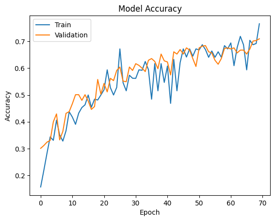

```python
# Plot accuracy
import matplotlib.pyplot as plt
plt.plot(history_3.history['accuracy'])
plt.plot(history_3.history['val_accuracy'])
plt.title('Model Accuracy')
plt.ylabel('Accuracy')
plt.xlabel('Epoch')
plt.legend(['Train', 'Validation'], loc='upper left')
plt.show()
```

**Observation**

- The model benefits from longer training, achieving higher accuracy and consistent performance on unseen data.

**Model evaluation on test data**

```python
accuracy = model3.evaluate(X_test_normalized, y_test_encoded, verbose=2)
print(f"Test Accuracy: {accuracy[1]*100:.2f}%")
```

```
15/15 - 0s - 27ms/step - accuracy: 0.7095 - loss: 0.9528
Test Accuracy: 70.95%
```

**Observation**

```
15/15 ━━━━━━━━━━━━━━━━━━━━ 2s 65ms/step
```

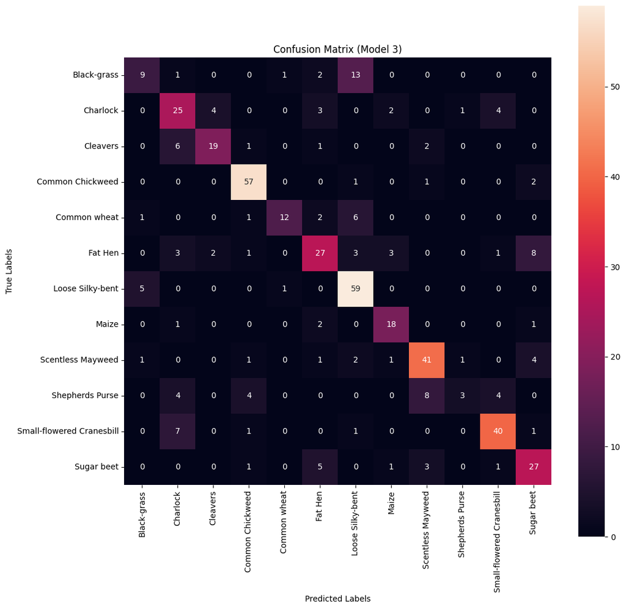

```python
# Confusion matrix for Model 2
y_pred3 = model3.predict(X_test_normalized)
y_pred_arg3 = np.argmax(y_pred3, axis=1)
y_test_arg3 = np.argmax(y_test_encoded, axis=1)
confusion_matrix3 = tf.math.confusion_matrix(y_test_arg3, y_pred_arg3)

plt.figure(figsize=(12, 12))
sns.heatmap(confusion_matrix3.numpy(), annot=True, fmt='d', square=True, xticklabels=enc.classes_, yticklabels=enc.classes_)
plt.xlabel('Predicted Labels')
plt.ylabel('True Labels')
plt.title('Confusion Matrix (Model 3)')
plt.show()
```

**Observation**

- Model 3 shows better balance and higher accuracy across most species, significantly reducing the number of extreme misclassifications seen in Models 1 and 2.

```python
# Classification report
print(metrics.classification_report(y_test_arg3, y_pred_arg3, target_names=enc.classes_))
```

```
                           precision    recall  f1-score   support

              Black-grass       0.56      0.35      0.43        26
                 Charlock       0.53      0.64      0.58        39
                 Cleavers       0.76      0.66      0.70        29
         Common Chickweed       0.85      0.93      0.89        61
             Common wheat       0.86      0.55      0.67        22
                  Fat Hen       0.63      0.56      0.59        48
         Loose Silky-bent       0.69      0.91      0.79        65
                    Maize       0.72      0.82      0.77        22
        Scentless Mayweed       0.75      0.79      0.77        52
          Shepherds Purse       0.60      0.13      0.21        23
Small-flowered Cranesbill       0.80      0.80      0.80        50
               Sugar beet       0.63      0.71      0.67        38

                 accuracy                           0.71       475
                macro avg       0.70      0.65      0.66       475
             weighted avg       0.71      0.71      0.69       475
```

**Observation**

1. Overall accuracy: 71%, showing a significant improvement over Model 1 (56%) and Model 2 (60%).
2. High-performing classes:
   - Common Chickweed (F1-score: 0.89) and Loose Silky-bent (F1-score: 0.79) indicate excellent classification.
   - Common wheat shows strong precision (0.86) but lower recall (0.55), suggesting it’s correctly predicted when detected but often missed.
3. Improved minority class performance: Black-grass (F1-score: 0.43) and Maize (F1-score: 0.77) demonstrate notable progress.
4. Weakest class: Shepherds Purse (F1-score: 0.21) with poor recall (0.13) indicates room for further improvement.

## Final Model

Comment on the final model you have selected and use the same in the below code to visualize the image.

Model Comparision - Model 1, Model 2, Model 3. -- **Model 3 has been selected **

1. Model 3 outperforms Model 1 and Model 2 in accuracy, precision, and F1-scores.
2. Minority and difficult classes (Black-grass, Common wheat, Maize) show progressive improvement across models.
3. Model 1: Underfitting, poor class balance, several classes with F1 = 0.
4. Model 2: Better generalization with augmentation, but still struggles with rare classes.
5. Model 3: Strong feature learning and class separation; most balanced performance.

### Visualizing the prediction

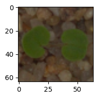

```
1/1 ━━━━━━━━━━━━━━━━━━━━ 4s 4s/step
Predicted Label: ['Small-flowered Cranesbill']
True Label: Small-flowered Cranesbill
```

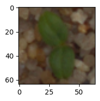

```
1/1 ━━━━━━━━━━━━━━━━━━━━ 0s 68ms/step
Predicted Label: ['Cleavers']
True Label: Cleavers
```

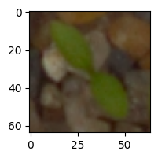

```
1/1 ━━━━━━━━━━━━━━━━━━━━ 0s 52ms/step
Predicted Label: ['Common Chickweed']
True Label: Common Chickweed
```

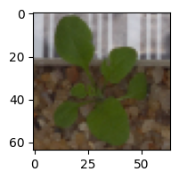

```
1/1 ━━━━━━━━━━━━━━━━━━━━ 0s 54ms/step
Predicted Label: ['Charlock']
True Label: Shepherds Purse
```

```python
# Visualizing the predicted and correct label of images from test data
plt.figure(figsize=(2,2))
plt.imshow(X_test[2])
plt.show()
## Predict the label for the test image
print('Predicted Label:', enc.inverse_transform(model3.predict(X_test_normalized[2].reshape(1, 64, 64, 3))))
print('True Label:', enc.inverse_transform(y_test_encoded)[2])

plt.figure(figsize=(2,2))
plt.imshow(X_test[33])
plt.show()
## Predict the label for the test image
print('Predicted Label:', enc.inverse_transform(model3.predict(X_test_normalized[33].reshape(1, 64, 64, 3))))
print('True Label:', enc.inverse_transform(y_test_encoded)[33])

plt.figure(figsize=(2,2))
plt.imshow(X_test[59])
plt.show()
## Predict the label for the test image
print('Predicted Label:', enc.inverse_transform(model3.predict(X_test_normalized[59].reshape(1, 64, 64, 3))))
print('True Label:', enc.inverse_transform(y_test_encoded)[59])

plt.figure(figsize=(2,2))
plt.imshow(X_test[36])
plt.show()
## Predict the label for the test image
print('Predicted Label:', enc.inverse_transform(model3.predict(X_test_normalized[36].reshape(1, 64, 64, 3))))
print('True Label:', enc.inverse_transform(y_test_encoded)[36])
```

## Actionable Insights and Business Recommendations

**Actionable Insights**

**Business Recommendations**

1. Deploy Model3 for operational use
   - Integrate the final model into mobile apps and drone-based monitoring systems for real-time plant species classification
2. Utilize the classifier for automated weed detection and crop health monitoring, reducing manual intervention and increasing farm productivity.
3. Create a feedback loop from field usage to capture and retrain the model on misclassified images, ensuring performance remains high as field conditions evolve.